# ASAP Case Study

Christine Stawitz and Bai Li

Created on 08/05/2019; Updated on 03/10/2021

## Install and library packages

```r
knitr::opts_chunk$set(echo = TRUE, fig.width=10, fig.height=10)

# remotes::install_github("nmfs-fish-tools/RMAS")
# devtools::install_github("cmlegault/ASAPplots", dependencies=FALSE)

library(RMAS)
library(Rcpp)
library(jsonlite)
library(ASAPplots)
```

## Read ASAP input file

```r
# Download a .zip file of the repository
temp <- tempdir()
url <- "https://github.com/Bai-Li-NOAA/RMAS/archive/master.zip"
download.file(
  url = "https://github.com/Bai-Li-NOAA/RMAS/archive/master.zip",
  destfile = file.path(temp, "RMAS-master.zip")
)

# Unzip the .zip file
unzip(zipfile = file.path(temp, "RMAS-master.zip"),
      exdir = temp)

# Read ASAP input data
data_dir <- file.path(temp, "RMAS-master", "vignettes", "003_ASAPCaseStudy")
asap_input <- ReadASAP3DatFile(file.path(data_dir, "ASAPSimple.dat"))$dat
```

```
## [1] "Hooray!  Test value at end of file is correct"
```

## Convert ASAP inputs to MAS inputs

```r
# Load RMAS module
r4mas <- Rcpp::Module("rmas", PACKAGE="RMAS")

# General settings
nyears <- asap_input$n_years

nseasons <- 1

nages <- asap_input$n_ages

ages <-  1:asap_input$n_ages

area1 <- new(r4mas$Area)
area1$name <- "area1"

# Recruitment settings
recruitment <- new(r4mas$BevertonHoltRecruitment)

recruitment$R0$value <- asap_input$SR_scalar_ini
recruitment$R0$estimated <-
  ifelse (asap_input$phase_SR_scalar<0, FALSE, TRUE)
recruitment$R0$phase <- abs(asap_input$phase_SR_scalar)

recruitment$h$value <- asap_input$steepness_ini
recruitment$h$estimated <-
  ifelse(asap_input$phase_steepness < 0, FALSE, TRUE)
recruitment$h$phase <- abs(asap_input$phase_steepness)
recruitment$h$min <- 0.2001
recruitment$h$max <- 1.0

recruitment$sigma_r$value <- exp(sqrt(log((asap_input$recruit_cv[1,])^2+1)))
recruitment$sigma_r$estimated <- FALSE
# recruitment$sigma_r$estimated <- TRUE # The estimated sigma_r and recruitment deviations are 0 when estimating sigma_r.
recruitment$sigma_r$min <- 0
recruitment$sigma_r$max <- 3
recruitment$sigma_r$phase <- 2

recruitment$estimate_deviations <-
  ifelse(asap_input$phase_rec_devs < 0, FALSE, TRUE)
recruitment$constrained_deviations <- TRUE
recruitment$deviations_min <- -15.0
recruitment$deviations_max <- 15.0
recruitment$deviation_phase <- abs(asap_input$phase_rec_devs)
recruitment$SetDeviations(rep(0.1, times=nyears))

# Growth settings
growth <- new(r4mas$VonBertalanffyModified)

fleet_num <- asap_input$n_fleets
catch_waa_pointer <- asap_input$WAA_pointers[fleet_num*2+1]
catch_empirical_weight <-
  as.vector(t(asap_input$WAA_mats[[catch_waa_pointer]])) # Total catch

ssb_waa_pointer <- asap_input$WAA_pointers[fleet_num*2+2+1]
ssb_empirical_weight <-
  as.vector(t(asap_input$WAA_mats[[ssb_waa_pointer]]))

jan1_waa_pointer <- asap_input$WAA_pointers[fleet_num*2+2+2]
jan1_empirical_weight <-
  as.vector(t(asap_input$WAA_mats[[jan1_waa_pointer]]))

survey_num <- 1 # How to create multiple survey empirical weight-at-age for different surveys? How to add the information to growth$SetUndifferentiatedSurveyWeight and population$SetGrowth?
#survey_num <- asap_input$n_indices
survey_empirical_weight <- vector(mode="list", length=survey_num)
for (i in 1:survey_num) {
  survey_waa_pointer <- asap_input$index_WAA_pointers[i]
  survey_waa <- as.vector(t(asap_input$WAA_mats[[survey_waa_pointer]]))

  if (asap_input$index_units[i]==1) {
    survey_empirical_weight[[i]] <- survey_waa
  } # Survey unit is biomass

  if (asap_input$index_units[i]==2) {
    survey_empirical_weight[[i]] <- replicate(nages*nyears, 1.0)
  } # Survey unit is number
}

growth$SetUndifferentiatedCatchWeight(catch_empirical_weight)
growth$SetUndifferentiatedWeightAtSeasonStart(jan1_empirical_weight)
growth$SetUndifferentiatedWeightAtSpawning(ssb_empirical_weight)
growth$SetUndifferentiatedSurveyWeight(survey_empirical_weight[[1]]) # How to set empirical weight-at-age for two surveys? One survey unit is biomass and the other survey unit is number. The data are stored in survey_empirical_weight list.

# Maturity settings
maturity <- new(r4mas$Maturity)
maturity$values <- asap_input$maturity[1,] # Time-invariant

# Natural mortality settings
natural_mortality <- new(r4mas$NaturalMortality)
natural_mortality$SetValues(asap_input$M[1,]) # Time-invariant

# Movement settings
movement <- new(r4mas$Movement)
movement$connectivity_females <- c(1.0)
movement$connectivity_males <- c(1.0)
movement$connectivity_recruits <- c(1.0)

# Initial deviations
initial_deviations <- new(r4mas$InitialDeviations)
initial_deviations$values <- rep(0.1, times=nages)
initial_deviations$estimate <-
  ifelse(asap_input$phase_N1_devs < 0, FALSE, TRUE)
initial_deviations$phase <- abs(asap_input$phase_N1_devs)

# Create population
population=new(r4mas$Population)
for (y in 0:(nyears-1))
{
  population$AddMovement(movement$id, y)
}

population$AddNaturalMortality(natural_mortality$id,area1$id,"undifferentiated")
population$AddMaturity(maturity$id,area1$id, "undifferentiated")
population$AddRecruitment(recruitment$id, 1, area1$id)
population$SetInitialDeviations(initial_deviations$id, area1$id, "undifferentiated")
population$SetGrowth(growth$id)
#population$sex_ratio <- 0.5

# Catch index values and observation errors
catch_index <- vector(mode="list", length=fleet_num)
for (i in 1:fleet_num){
  catch_index[[i]] <- new(r4mas$IndexData)
  catch_index[[i]]$values <- asap_input$CAA_mats[[i]][, (nages+1)]
  catch_index[[i]]$error <- asap_input$catch_cv[, i]
}

# Catch composition data
catch_comp <- vector(mode="list", length=fleet_num)
for (i in 1:fleet_num){
  catch_comp[[i]] <- new(r4mas$AgeCompData)
  catch_comp[[i]]$values <- as.vector(t(asap_input$CAA_mats[[i]][, (1:nages)]))
  catch_comp[[i]]$sample_size <- asap_input$catch_Neff[, i]
}

# Likelihood component settings
fleet_index_comp_nll <- vector(mode="list", length=fleet_num)
fleet_age_comp_nll <- vector(mode="list", length=fleet_num)
for (i in 1:fleet_num){
  fleet_index_comp_nll[[i]] <- new(r4mas$Lognormal)
  fleet_index_comp_nll[[i]]$use_bias_correction <- FALSE

  fleet_age_comp_nll[[i]] <- new(r4mas$Multinomial)
}


# # Fleet selectivity settings
fleet_selectivity <- vector(mode="list", length=fleet_num)
for (i in 1:fleet_num){
  selectivity_option <- asap_input$sel_block_option[i]

  if (selectivity_option==1) {
    fleet_selectivity[[i]] <- new(r4mas$AgeBasedSelectivity)
    fleet_selectivity[[i]]$estimated <- TRUE # if it is age based selectivity, can you estimate some values and fix the other values?
    fleet_selectivity[[i]]$phase <- 2 # if it is age based selectivity, can you estimate some values and fix the other values?
    # fleet_selectivity$estimated <-
    #   ifelse(asap_input$sel_ini[[i]][(1:nages), 2] < 0, FALSE, TRUE)
    # fleet_selectivity$phase <- asap_input$sel_ini[[i]][(1:nages), 2]
    fleet_selectivity[[i]]$values <- asap_input$sel_ini[[i]][(1:nages),1]
  }

  if (selectivity_option==2) {
    fleet_selectivity[[i]] <- new(r4mas$LogisticSelectivity)
    fleet_selectivity[[i]]$a50$value <- asap_input$sel_ini[[i]][(nages+2), 1]
    fleet_selectivity[[i]]$a50$estimated <-
      ifelse(asap_input$sel_ini[[i]][(nages+2), 2] < 0, FALSE, TRUE)
    fleet_selectivity[[i]]$a50$phase <- asap_input$sel_ini[[i]][(nages+2), 2]
    fleet_selectivity[[i]]$a50$min <- 0.0001
    fleet_selectivity[[i]]$a50$max <- nages

    fleet_selectivity[[i]]$slope$value <- asap_input$sel_ini[[i]][(nages+1), 1]
    fleet_selectivity[[i]]$slope$estimated <- ifelse(asap_input$sel_ini[[i]][(nages+1), 2] < 0, FALSE, TRUE)
    fleet_selectivity[[i]]$slope$phase <- asap_input$sel_ini[[i]][(nages+1), 2]
    fleet_selectivity[[i]]$slope$min <- 0.0001
    fleet_selectivity[[i]]$slope$max <- nages
  }

 # Add double-logistic case later

}

# Fishing mortality settings
fishing_mortality <- new(r4mas$FishingMortality)
fishing_mortality$estimate <- TRUE
fishing_mortality$phase <- asap_input$phase_F1
fishing_mortality$min <- 0.0
fishing_mortality$max <- asap_input$Fmax
fishing_mortality$SetValues(rep(asap_input$F1_ini, nyears))

# Create the fleet
fleet <- vector(mode="list", length=fleet_num)

for (i in 1:fleet_num){
  fleet[[i]] <- new(r4mas$Fleet)
  fleet[[i]]$AddIndexData(catch_index[[i]]$id, "undifferentiated")
  fleet[[i]]$AddAgeCompData(catch_comp[[i]]$id, "undifferentiated")
  fleet[[i]]$SetIndexNllComponent(fleet_index_comp_nll[[i]]$id)
  fleet[[i]]$SetAgeCompNllComponent(fleet_age_comp_nll[[i]]$id)
  fleet[[i]]$AddSelectivity(fleet_selectivity[[i]]$id, 1, area1$id)
  fleet[[i]]$AddFishingMortality(fishing_mortality$id, 1, area1$id)
}


# Survey index values and observation errors
survey_index <- vector(mode="list", length=survey_num)
for (i in 1:survey_num){
  survey_index[[i]] <- new(r4mas$IndexData)
  survey_index[[i]]$values <- asap_input$IAA_mats[[i]][,2]
  survey_index[[i]]$error <- asap_input$IAA_mats[[i]][,3]
}

# Survey composition
survey_comp <- vector(mode="list", length=survey_num)
for (i in 1:survey_num){
  survey_comp[[i]] <- new(r4mas$AgeCompData)
  survey_comp[[i]]$values <- asap_input$IAA_mats[[i]][,4:(4+nages-1)]
  survey_comp[[i]]$sample_size <- asap_input$IAA_mats[[i]][,(4+nages)]
}

# Likelihood component settings
survey_index_comp_nll <- vector(mode="list", length=survey_num)
survey_age_comp_nll <- vector(mode="list", length=survey_num)
for (i in 1:survey_num){
  survey_index_comp_nll[[i]] <- new(r4mas$Lognormal)
  survey_index_comp_nll[[i]]$use_bias_correction <- FALSE

  survey_age_comp_nll[[i]] <- new(r4mas$Multinomial)
}

# Survey selectivity settings
survey_selectivity <- vector(mode="list", length=survey_num)
for (i in 1:survey_num){
  selectivity_option <- asap_input$index_sel_option[i]

  if (selectivity_option==1) {
    survey_selectivity[[i]] <- new(r4mas$AgeBasedSelectivity)
    survey_selectivity[[i]]$estimated <- FALSE # if it is age based selectivity, can you estimate some values and fix the other values?
    survey_selectivity[[i]]$phase <- 1
    # survey_selectivity[[i]]$estimated <- ifelse(asap_input$index_sel_ini[[i]][(1:nages), 2] < 0, FALSE, TRUE)
    # survey_selectivity[[i]]$phase <- asap_input$index_sel_ini[[i]][(1:nages), 2]
    survey_selectivity[[i]]$values <- asap_input$index_sel_ini[[i]][(1:nages),1]

  }

  if (selectivity_option==2) {
    survey_selectivity[[i]] <- new(r4mas$LogisticSelectivity)
    survey_selectivity[[i]]$a50$value <- asap_input$index_sel_ini[[i]][(nages+2), 1]
    survey_selectivity[[i]]$a50$estimated <- ifelse(asap_input$index_sel_ini[[i]][(nages+2), 2] < 0, FALSE, TRUE)
    survey_selectivity[[i]]$a50$phase <- asap_input$index_sel_ini[[i]][(nages+2), 2]
    survey_selectivity[[i]]$a50$min <- 0.0001
    survey_selectivity[[i]]$a50$max <- nages

    survey_selectivity[[i]]$slope$value <- asap_input$index_sel_ini[[i]][(nages+1), 1]
    survey_selectivity[[i]]$slope$estimated <- ifelse(asap_input$index_sel_ini[[i]][(nages+1), 2] < 0, FALSE, TRUE)
    survey_selectivity[[i]]$slope$phase <- asap_input$index_sel_ini[[i]][(nages+1), 2]
    survey_selectivity[[i]]$slope$min <- 0.0001
    survey_selectivity[[i]]$slope$max <- nages
  }

  # Add double-logistic case later

}

# Create the survey
survey <- vector(mode="list", length=survey_num)
for (i in 1:survey_num){
  survey[[i]] <- new(r4mas$Survey)

  survey[[i]]$AddIndexData(survey_index[[i]]$id, "undifferentiated")
  survey[[i]]$AddAgeCompData(survey_comp[[i]]$id, "undifferentiated")
  survey[[i]]$SetIndexNllComponent(survey_index_comp_nll[[i]]$id)
  survey[[i]]$SetAgeCompNllComponent(survey_age_comp_nll[[i]]$id)
  survey[[i]]$AddSelectivity(survey_selectivity[[i]]$id, 1, area1$id)

  survey[[i]]$q$value <- asap_input$q_ini[i]/1000
  survey[[i]]$q$min <- 0
  survey[[i]]$q$max <- 10
  survey[[i]]$q$estimated <- ifelse(asap_input$phase_q<0, FALSE, TRUE)
  survey[[i]]$q$phase <- abs(asap_input$phase_q)
}
```

## Build the MAS model

```r
mas_model <- new(r4mas$MASModel)

mas_model$nyears <- nyears
mas_model$nseasons <- nseasons
mas_model$nages <- nages
mas_model$extended_plus_group <- max(ages)
mas_model$ages <- ages
mas_model$catch_season_offset <- 0.0
mas_model$spawning_season_offset <- asap_input$fracyr_spawn
mas_model$survey_season_offset <- (asap_input$index_month[1]-1)/12

mas_model$AddPopulation(population$id)

for (i in 1:fleet_num){
  mas_model$AddFleet(fleet[[i]]$id)
}

for (i in 1:survey_num){
  mas_model$AddSurvey(survey[[i]]$id)
}
```

## Run `MAS`, save `MAS` outputs, and reset `MAS`

```r
# Run MAS
mas_model$Run()

# Write MAS outputs to a json file
write(mas_model$GetOutput(),
      file=file.path(data_dir, "mas_output.json"))

# Reset MAS for next run
mas_model$Reset()

# Import MAS output
mas_output <- jsonlite::read_json(file.path(data_dir, "mas_output.json"))
```

## Aggregate estimates of key variables from the `ASAP`

```r
# Read ASAP outputs
asap_output <- dget(file.path(data_dir, "asap3.rdat"))

asap <- list()

asap$biomass <- asap_output$tot.jan1.B
asap$abundance <- apply(asap_output$N.age, 1, sum)
asap$ssb <- asap_output$SSB
asap$recruit <- asap_output$N.age[,1]
asap$f <- apply(asap_output$fleet.FAA$FAA.directed.fleet1, 1, max)
asap$landing <- asap_output$catch.pred
asap$survey <- asap_output$index.pred$ind01
asap$agecomp <- apply(asap_output$N.age, 1, function(x) x/sum(x))
asap$r0 <- asap_output$SR.parms$SR.R0
asap$q <- asap_output$q.indices[1]
```

## Aggregate estimates of key variables from the `MAS`

```r
parameter <- unlist(mas_output$estimated_parameters$parameters)
parameter_table <- as.data.frame(matrix(parameter, ncol=3, byrow=TRUE))
colnames(parameter_table) <- c("Parameter",
                               "Value",
                               "Gradient")
parameter_table$Value <- round(as.numeric(parameter_table$Value),
                                digits = 6)
parameter_table$Gradient <- round(as.numeric(parameter_table$Gradient),
                                digits = 6)

parameter_table
```

```
##                       Parameter     Value    Gradient
## 1                           q_1  0.511127   -0.019617
## 2   recruitment_deviations[0]_1 -0.922631    0.195643
## 3   recruitment_deviations[1]_1 -0.846598   -0.484903
## 4   recruitment_deviations[2]_1 -1.447953   -0.323429
## 5   recruitment_deviations[3]_1 -0.920269   -0.817349
## 6   recruitment_deviations[4]_1 -1.484838   -0.534608
## 7   recruitment_deviations[5]_1  0.584151   -5.550675
## 8   recruitment_deviations[6]_1 -0.575677   -2.122927
## 9   recruitment_deviations[7]_1 -1.005562   -1.734690
## 10  recruitment_deviations[8]_1 -0.582129   -3.359703
## 11  recruitment_deviations[9]_1 -1.809166   -1.216506
## 12 recruitment_deviations[10]_1 -0.386803   -6.510442
## 13 recruitment_deviations[11]_1 -0.886700   -4.314450
## 14 recruitment_deviations[12]_1 -0.717562   -4.850915
```

[output cut: 61 more lines]

```r
popdy<-mas_output$population_dynamics
pop<-popdy$populations[[1]]
flt<-popdy$fleets[[1]]
srvy<-popdy$surveys[[1]]

mas <- list()

mas$biomass <- unlist(pop$undifferentiated$biomass$values)
mas$abundance <- unlist(pop$undifferentiated$abundance$values)
mas$ssb <- unlist(pop$undifferentiated$spawning_stock_biomass$values)
mas$recruit <- unlist(pop$undifferentiated$recruits$values)
mas$f <- unlist(pop$undifferentiated$fishing_mortality$values)
mas$landing <- unlist(flt$undifferentiated$catch_biomass$values)
mas$survey <- unlist(srvy$undifferentiated$survey_biomass$values)
mas$agecomp <- apply(
  matrix(unlist(pop$undifferentiated$numbers_at_age$values),
         nrow=popdy$nyears,
         ncol=popdy$nages,
         byrow = T),
  1,
  function(x) x/sum(x))
mas$r0 <- exp(parameter_table$Value[parameter_table$Parameter=="log_R0_1"])
mas$q <- list(parameter_table$Value[parameter_table$Parameter=="q_1"])
```

## Generate comparison figures

Compare temporal trends of biomass(B), abundance(A), spawning stock biomass (SSB), recruit (R), fishing mortality (F), Landings (L), and Survey index (SI) from `ASAP` (dots) and `MAS` (lines).

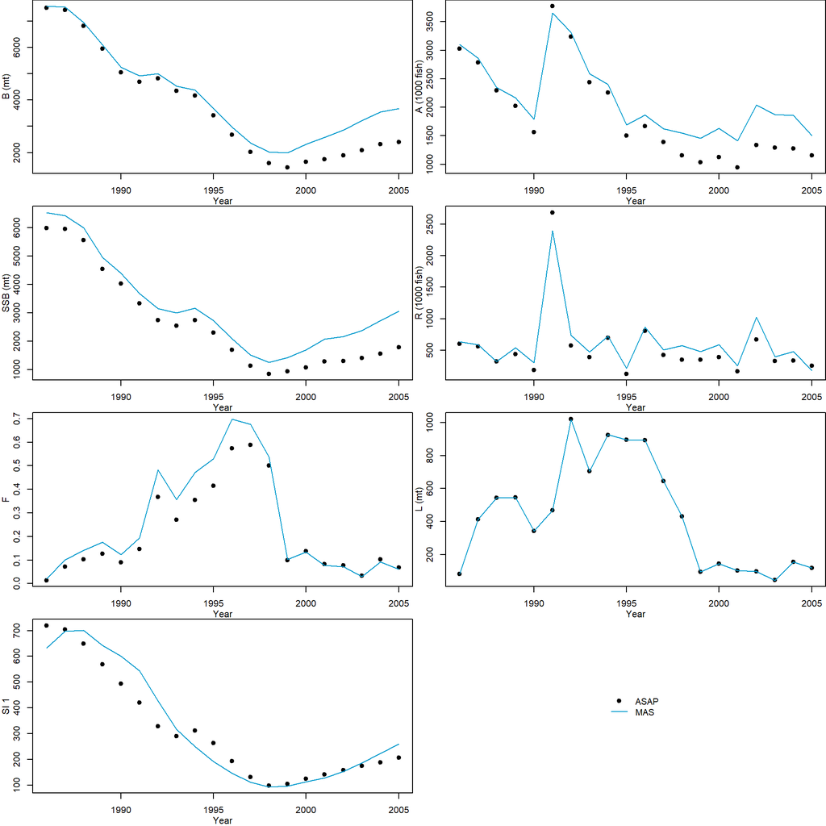

```r
years <- as.numeric(rownames(asap_output$N.age))
par(mfrow=c(4, 2), mar=c(3, 3, 0, 0))
var <- c("biomass", "abundance", "ssb", "recruit", "f",
         "landing", "survey")
ylab <- c("B (mt)", "A (1000 fish)",
          "SSB (mt)", "R (1000 fish)",
          "F", "L (mt)", "SI 1")
for(i in 1:length(var)){
  ylim = range(asap[[var[i]]], mas[[var[i]]])
  plot(years, asap[[var[i]]],
       xlab="", ylab="",
       ylim=ylim, pch=19)
  lines(years, mas[[var[i]]],
        col="deepskyblue3", lty=1)
  mtext("Year", side=1, line=2, cex=0.7)
  mtext(ylab[i], side=2, line=2, cex=0.7)
}
plot.new()
legend("center",
       c("ASAP", "MAS"),
       pch=c(19, NA),
       lty=c(NA, 1),
       col=c("black", "deepskyblue3"),
       bty="n")
```

Compare age composition from the `ASAP` (dots) and `MAS` (lines).

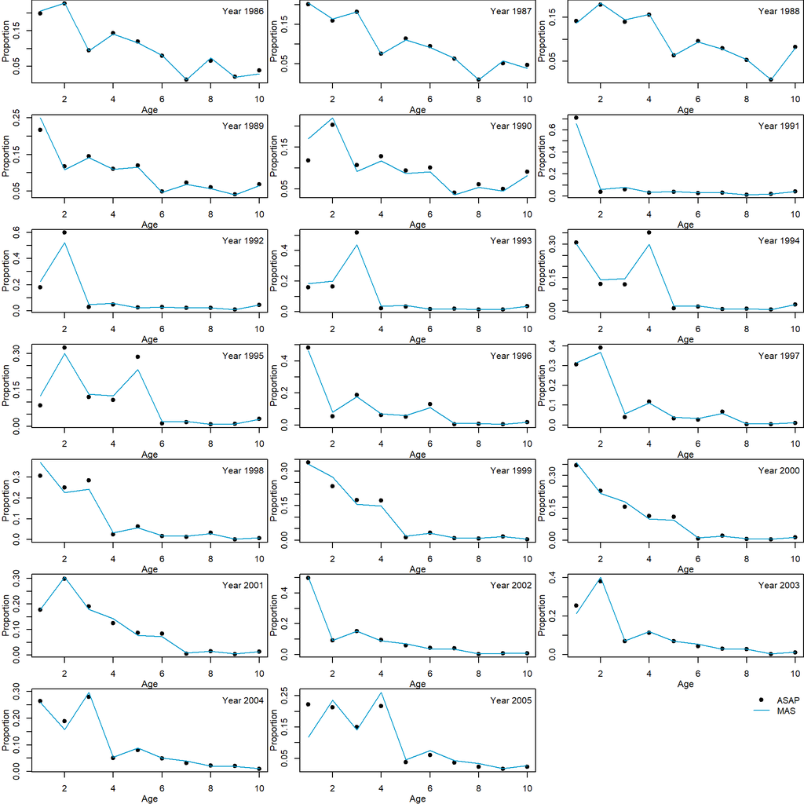

```r
par(mfrow=c(7, 3), mar=c(3, 3, 0, 0))
var <- c("agecomp")
ylab <- c("Proportion")
for(i in 1:ncol(asap[[var]])){
  ylim = range(asap[[var]][,i], mas[[var]][,i])
  plot(ages, asap[[var]][,i],
       xlab="", ylab="",
       ylim=ylim, pch=19)
  lines(ages, mas[[var]][,i],
        col="deepskyblue3", lty=1)
  mtext("Age", side=1, line=2, cex=0.7)
  mtext(ylab, side=2, line=2, cex=0.7)
  legend("topright",
         paste("Year", years[i]),
         bty="n")
}
plot.new()
legend("topright",
       c("ASAP", "MAS"),
       pch=c(19, NA),
       lty=c(NA, 1),
       col=c("black", "deepskyblue3"),
       bty="n")
```

## Questions

### RMAS inputs and outputs

- When `recruitment$sigma_r$estimated` is TRUE in RMAS, the estimated sigma_r and recruitment deviations are 0. Are there any additional settings needed when estimating sigma_r?
- How to create multiple survey empirical weight-at-age vectors and link them with growth settings (e.g., `growth$SetUndifferentiatedSurveyWeight`) and population settings (e.g., `population$SetGrowth`) when there is only one population? Can different fleets use different empirical weight-at-age matrices?
- Is the `population$AddMovement` supposed to start from year 0 or 1?
- How is sex ratio used in MAS? ASAP doesn't distinguish males and females. ASAP multiplies maturity-at-age with sex ratio to get female spawning stock biomass. In this example, ASAP doesn't use sex ratio and R stops working when population$sex_ratio equals 1 in RMAS.
- For age-based selectivity, can you estimate it for some ages and fix it for some ages?
- How to link `r4mas$FishingMortality` with fleet (e.g., `fleet$AddFishingMortality`) when there are more than 1 fleet?
- Include parameter names for age-based selectivity in RMAS outputs?

### Potential causes of differences between ASAP and MAS estimates

- ASAP uses data from two surveys but MAS only uses data from survey 1 at the current stage.
- Selectivity of fleet is age-based selectivity. In ASAP, the selectivity from age 7-10 is fixed at 1. In MAS, the selectivity from age 1-10 is estimated.